# Optimal Pitch Mechanics for Maximising Velocity

### 3.1.4 Max External Rotation (`*_mer`)

| Variable | Description |
| --- | --- |
| `glove_shoulder_abduction_mer` | Glove-shoulder abduction (°) |
| `elbow_flexion_mer` | Elbow flexion (°) |
| `torso_anterior_tilt_mer` | Trunk flexion (°) |
| `torso_lateral_tilt_mer` | Trunk lateral flexion (°) |
| `torso_rotation_mer` | Trunk axial rotation (°) |

### 3.1.5 Ball Release (`*_br`)

| Variable | Description |
| --- | --- |
| `lead_knee_extension_angular_velo_br` | Lead-knee ext. velocity (°/s) |
| `torso_anterior_tilt_br` | Trunk flexion (°) |
| `torso_lateral_tilt_br` | Trunk lateral flexion (°) |
| `torso_rotation_br` | Trunk axial rotation (°) |

### 3.1.6 Timing & Stride

| Variable | Description |
| --- | --- |
| `lead_knee_extension_from_fp_to_br` | Δ Lead-knee ext. (°) |
| `timing_peak_torso_to_peak_pelvis_rot_velo` | Time peak pelvis → peak torso (s) |
| `stride_length` | Stride length (% body ht) |
| `stride_angle` | Stride angle (°; + = cross-body) |
| `arm_slot` | Arm slot (forearm proj. angle, °) |
| `cog_velo_pkh` | CoG velocity at peak-knee-height (m/s) |

### 3.1.7 Joint Energy (Foot Plant → Ball Release)

| Variable | Description |
| --- | --- |
| `shoulder_transfer_fp_br` / `generation` / `absorption` | Shoulder energy (J) |
| `elbow_transfer_fp_br` / `generation` / `absorption` | Elbow energy (J) |
| `lead_hip_transfer_fp_br` / `generation` / `absorption` | Lead-hip energy (J) |
| `lead_knee_transfer_fp_br` / `generation` / `absorption` | Lead-knee energy (J) |
| `rear_hip_transfer_pkh_fp` / `generation` / `absorption` | Rear-hip energy (J) |
| `rear_knee_transfer_pkh_fp` / `generation` / `absorption` | Rear-knee energy (J) |
| `pelvis_lumbar_transfer_fp_br` | Pelvis → trunk energy (J) |
| `thorax_distal_transfer_fp_br` | Trunk → shoulder energy (J) |

### 3.1.8 Moments

| Variable | Description |
| --- | --- |
| `elbow_varus_moment` | Peak elbow varus moment (N·m) |
| `shoulder_internal_rotation_moment` | Peak shoulder IR moment (N·m) |

### 3.1.9 Ground-Reaction Forces (peak)

| Variable | Description |
| --- | --- |
| `rear_grf_x_max` / `y_max` / `z_max` / `mag_max` | Rear-leg GRF components (N) |
| `rear_grf_angle_at_max` | Rear-GRF vector angle (°) |
| `lead_grf_x_max` / `y_max` / `z_max` / `mag_max` | Lead-leg GRF components (N) |
| `lead_grf_angle_at_max` | Lead-GRF vector angle (°) |

## 3.2 Outcome distribution

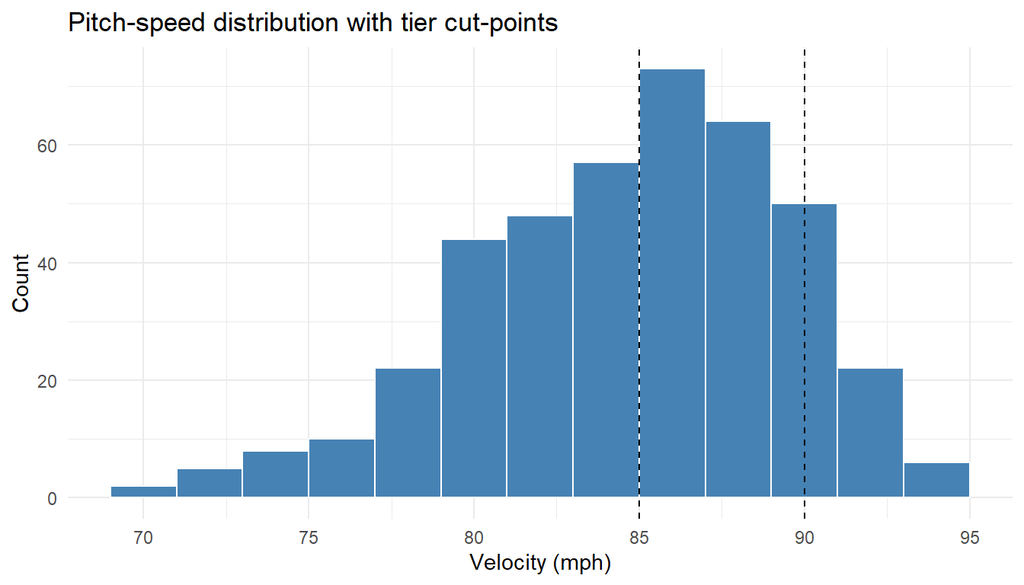

```r
raw %>%
  ggplot(aes(pitch_speed_mph)) +
  geom_histogram(binwidth = 2, fill = "steelblue", colour = "white") +
  geom_vline(xintercept = c(85, 90), linetype = "dashed") +
  labs(title = "Pitch-speed distribution with tier cut-points",
       x = "Velocity (mph)", y = "Count") +
  theme_minimal()
```

## 3.3 Top correlations

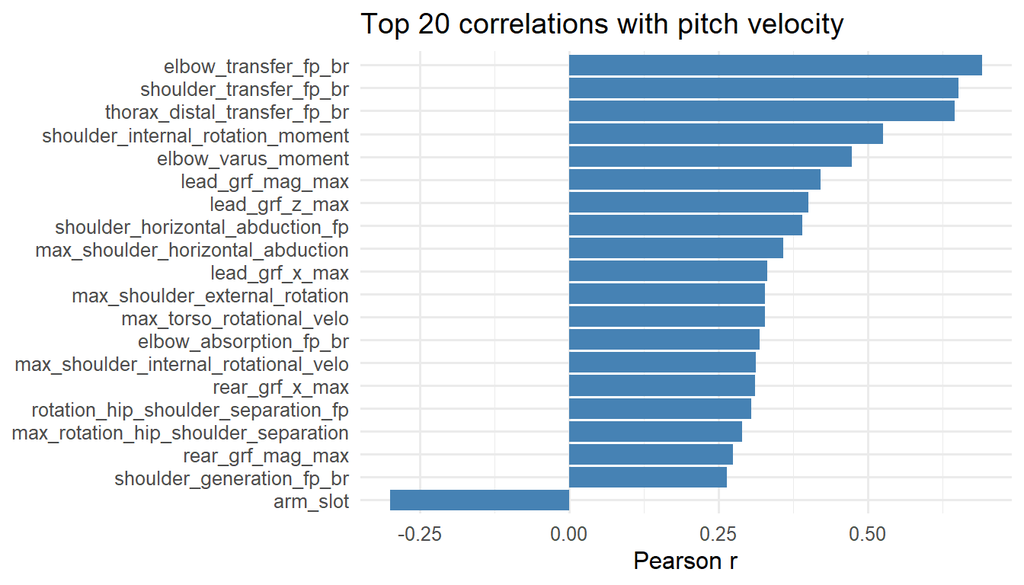

```r
raw %>%
  select(where(is.numeric)) %>%
  correlate() %>%
  focus(pitch_speed_mph) %>%
  rename(r = pitch_speed_mph) %>%
  arrange(-abs(r)) %>%
  slice_head(n = 20) %>%
  mutate(term = fct_reorder(term, r)) %>%
  ggplot(aes(x = term, y = r)) +
  geom_col(fill = "steelblue") +
  coord_flip() +
  labs(title = "Top 20 correlations with pitch velocity",
       x = NULL, y = "Pearson r") +
  theme_minimal(base_size = 12)
```

# 4 Data preparation

```r
velo_tier <- function(x) cut(
  x,
  breaks  = c(-Inf, 85, 90, Inf),
  labels  = c("Low", "Medium", "High"),
  right   = FALSE
)

pitch_df <- raw %>%
  select(-session_pitch, -session, -p_throws, -pitch_type) %>%
  drop_na() %>%
  mutate(velo_class = velo_tier(pitch_speed_mph))

pitch_split <- initial_split(pitch_df, prop = 0.8, strata = pitch_speed_mph)
train_data  <- training(pitch_split)
test_data   <- testing(pitch_split)

cv_folds <- vfold_cv(train_data, v = 5, strata = pitch_speed_mph)
```

# 5 Modelling

## 5.1 Random-forest regression (primary)

```r
rf_spec <- rand_forest(mtry = tune(), min_n = tune(), trees = 1000) %>%
  set_engine("ranger") %>%
  set_mode("regression")

rf_recipe <- recipe(pitch_speed_mph ~ ., data = train_data) %>%
  step_rm(velo_class) %>%
  step_nzv(all_predictors())

rf_wflow <- workflow() %>%
  add_recipe(rf_recipe) %>%
  add_model(rf_spec)

rf_grid <- grid_regular(
  mtry(range   = c(5, 25)),
  min_n(range = c(2, 10)),
  levels       = 5
)

rf_res  <- tune_grid(
  rf_wflow,
  resamples = cv_folds,
  grid      = rf_grid,
  metrics   = metric_set(rmse, rsq)
)

rf_best  <- select_best(rf_res, metric = "rmse")
rf_final <- finalize_workflow(rf_wflow, rf_best) %>% fit(train_data)
```

### 5.1.1 Hold-out metrics

```r
rf_hold <- rf_final %>%
  predict(test_data) %>%
  bind_cols(test_data)

rf_hold %>% metrics(truth = pitch_speed_mph, estimate = .pred)
```

```
## # A tibble: 3 × 3
##   .metric .estimator .estimate
##   <chr>   <chr>          <dbl>
## 1 rmse    standard       1.86
## 2 rsq     standard       0.859
## 3 mae     standard       1.34
```

### 5.1.2 Tier metrics

```r
rf_hold %>%
  mutate(pred_tier = velo_tier(.pred)) %>%
  metrics(truth = velo_class, estimate = pred_tier)
```

```
## # A tibble: 2 × 3
##   .metric  .estimator .estimate
##   <chr>    <chr>          <dbl>
## 1 accuracy multiclass     0.817
## 2 kap      multiclass     0.677
```

## 5.2 Polynomial, step-function, and spline demos (single variable)

Many coaching conversations revolve around **one key mechanic at a time**. To illustrate how classical regression handles non-linearity, I am going to isolate the *single* mechanical variable most correlated with velocity and fit three small models: polynomial expansion, discretised (step) function, and B-spline.

```r
best_mech <- train_data %>%
  select(-pitch_speed_mph, -velo_class) %>%
  summarise(across(everything(),
                   ~cor(.x, train_data$pitch_speed_mph,
                        use = "complete.obs"))) %>%
  pivot_longer(everything(),
               names_to  = "var",
               values_to = "cor") %>%
  arrange(desc(abs(cor))) %>%
  slice_head(n = 1) %>%
  pull(var)

best_mech
```

```
## [1] "elbow_transfer_fp_br"
```

### 5.2.1 Fourth-degree polynomial

```r
poly_rec <- recipe(
  pitch_speed_mph ~ .,
  data = train_data %>% select(pitch_speed_mph, !!sym(best_mech))
) %>%
  step_poly(all_predictors(), degree = 4)

lm_spec  <- linear_reg() %>% set_engine("lm")

poly_wf  <- workflow() %>%
  add_recipe(poly_rec) %>%
  add_model(lm_spec)

poly_fit <- fit(poly_wf, data = train_data)
```

### 5.2.2 Step function (4 bins, equal count)

```r
step_rec <- recipe(
  pitch_speed_mph ~ .,
  data = train_data %>% select(pitch_speed_mph, !!sym(best_mech))
) %>%
  step_discretize(all_predictors(), num_breaks = 4)

step_wf  <- workflow() %>%
  add_recipe(step_rec) %>%
  add_model(lm_spec)

step_fit <- fit(step_wf, data = train_data)
```

### 5.2.3 B-spline (5 degrees of freedom)

```r
spline_rec <- recipe(
  pitch_speed_mph ~ .,
  data = train_data %>% select(pitch_speed_mph, !!sym(best_mech))
) %>%
  step_bs(all_predictors(), deg_free = 5)

spline_wf  <- workflow() %>%
  add_recipe(spline_rec) %>%
  add_model(lm_spec)

spline_fit <- fit(spline_wf, data = train_data)
```

## 5.3 MARS (multivariate adaptive regression splines)

```r
mars_spec <- mars() %>% set_mode("regression")

mars_wf <- workflow() %>%
  add_model(mars_spec) %>%
  add_formula(pitch_speed_mph ~ .)  # earth cannot use recipes

mars_res <- fit_resamples(
  mars_wf, resamples = cv_folds,
  metrics  = metric_set(rmse, rsq)
)

collect_metrics(mars_res)
```

```
## # A tibble: 2 × 6
##   .metric .estimator  mean     n std_err .config
##   <chr>   <chr>      <dbl> <int>   <dbl> <chr>
## 1 rmse    standard   1.44      5 0.0517  Preprocessor1_Model1
## 2 rsq     standard   0.908     5 0.00965 Preprocessor1_Model1
```

# 6 Results

## 6.2 Visual comparison of single-variable regression models

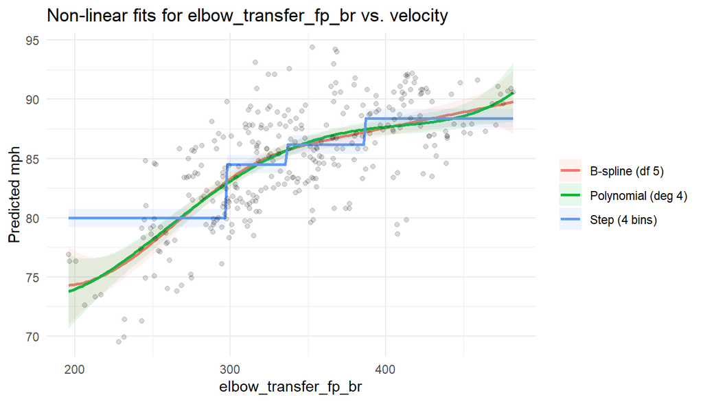

```r
x_seq <- tibble(
  !!best_mech := seq(min(train_data[[best_mech]]),
                     max(train_data[[best_mech]]),
                     length.out = 200)
)

poly_lines <- bind_cols(
  augment(poly_fit,   new_data = x_seq),
  predict(poly_fit,   new_data = x_seq, type = "conf_int")
) %>% mutate(model = "Polynomial (deg 4)")

step_lines <- bind_cols(
  augment(step_fit,   new_data = x_seq),
  predict(step_fit,   new_data = x_seq, type = "conf_int")
) %>% mutate(model = "Step (4 bins)")

spline_lines <- bind_cols(
  augment(spline_fit, new_data = x_seq),
  predict(spline_fit, new_data = x_seq, type = "conf_int")
) %>% mutate(model = "B-spline (df 5)")

bind_rows(poly_lines, step_lines, spline_lines) %>%
  ggplot(aes_string(x = best_mech, y = ".pred", colour = "model")) +
  geom_line(size = 1) +
  geom_ribbon(aes(ymin = .pred_lower, ymax = .pred_upper, fill = model),
              alpha = 0.1, colour = NA) +
  geom_point(data = train_data,
             aes_string(x = best_mech, y = "pitch_speed_mph"),
             alpha = 0.15, inherit.aes = FALSE) +
  labs(title = paste0("Non-linear fits for ", best_mech, " vs. velocity"),
       y = "Predicted mph", colour = NULL, fill = NULL) +
  theme_minimal()
```

## 6.3 Optimal range for variables

```r
opt_range <- function(fitted_wflow,
                      train_df,
                      vars        = NULL,
                      mph_tol     = 0.5,
                      grid_size   = 50) {

  rf_fit  <- extract_fit_parsnip(fitted_wflow)
  train_x <- bake(
    extract_recipe(fitted_wflow),
    new_data = train_df
  ) %>%
    select(-pitch_speed_mph)

  if (is.null(vars)) {
    vars <- train_x %>% select(where(is.numeric)) %>% names()
  }

  map_dfr(vars, function(v) {
    pd <- partial(
      rf_fit$fit,
      pred.var        = v,
      train           = train_x,
      grid.resolution = grid_size,
      progress        = "none"
    )

    peak <- max(pd$yhat, na.rm = TRUE)

    pd %>%
      filter(yhat >= peak - mph_tol) %>%
      summarise(
        variable = v,
        opt_min  = min(.data[[v]], na.rm = TRUE),
        opt_max  = max(.data[[v]], na.rm = TRUE)
      )
  })
}

vars_of_interest <- c(
  "elbow_transfer_fp_br",
  "max_shoulder_horizontal_abduction",
  "torso_rotation_br",
  "lead_knee_extension_from_fp_to_br",
  "elbow_flexion_fp"
)

opt_tbl <- opt_range(rf_final, train_data, vars = vars_of_interest)

knitr::kable(
  opt_tbl,
  digits    = 2,
  col.names = c("Variable", "Optimal min", "Optimal max")
)
```

| Variable | Optimal min | Optimal max |
| --- | --- | --- |
| elbow_transfer_fp_br | 318.56 | 482.07 |
| max_shoulder_horizontal_abduction | 30.46 | 75.82 |
| torso_rotation_br | 93.69 | 144.43 |
| lead_knee_extension_from_fp_to_br | -17.71 | 55.19 |
| elbow_flexion_fp | 50.33 | 137.98 |

The table above shows the **optimal mechanical ranges** that a pitcher should strive for, based on the random-forest partial-dependence analysis. `elbow_transfer_fp_br` is measured in joules; the other variables are measured in degrees (see variable glossary in the EDA).

# 7 Conclusion

## 7.2 Practical guidelines

[output not shown]

## 7.4 Future research directions

- **Augment metadata** with pitcher weight, strength scores, pitch counts, and training history to normalise for athlete capacity.
- **Validate optimal-range tables** in live bullpens: do pitchers who migrate toward our recommended bands gain velocity without elevated joint torques?

# 8 AI reflective statement

I used AI for a couple of different things in this project. Although most of the code for the regression models that I used was from class activities, I was getting errors that I couldn’t find the solution to. I used chatGPT to help resolve the error in the recipe. I was not familiar with how to code the part for finding the best ranges for the different pitch mechanics and chatGPT was able to help me with exactly what I was wanting to accomplish with this part of the project. I also used AI to help me format the final draft. This included getting the format so the r markdown was written in a way that it would be easy to read when knitted to html as well as editing any grammatical mistakes in the writing. I finally used AI to help me with the plot in the results secton for comparing the different regression models. Overall, I thought that AI was very helpful in assisting my project. I would say that I felt very comfortable with understanding the data with it being about baseball, meaning that any code for models and plots that AI could help me with, I would have an understanding of if the results made sense in the context of the data. For that reason I felt comfortable using it, but if it were data that I was less familar with, I would have been more careful with it for sure.